# Visualizing the iris flower data set

A true perfectionist never settles. We notice a strong linear correlation between petal length and width. Let’s add a trend line using **abline()**, a low level graphics function.

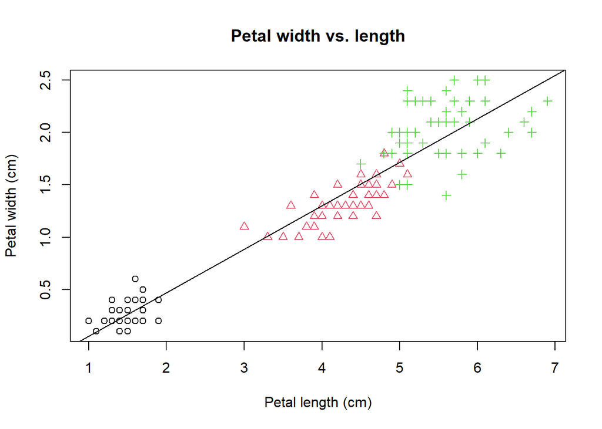

```r
abline(lm(PW ~ PL)) # the order is reversed as we need y ~ x.
```

The `lm(PW ~ PL)` generates a linear model (lm) of petal width as a function petal length. y ~ x is **formula notation** that used in many different situations. This linear regression model is used to plot the trend line.

We calculate the Pearson’s correlation coefficient and mark it to the plot.

```r
PCC <- cor(PW, PL) # Pearson's correlation coefficient
PCC <- round(PCC, 2) # round to the 2nd place after decimal point.
paste("R =", PCC)
```

```
## [1] "R = 0.96"
```

The *paste* function glues two strings together. Then we use the **text** function to place strings at lower right by specifying the coordinate of (x=5, y=0.5).

(ref:23-5) A refined scatter plot using base R graphics.

```r
text(5, 0.5, paste("R=", PCC)) # add text annotation.
legend("topleft", # specify the location of the legend
  levels(iris$Species), # specify the levels of species
  pch = 1:3, # specify three symbols used for the three species
  col = 1:3 # specify three colors for the three species
)
```

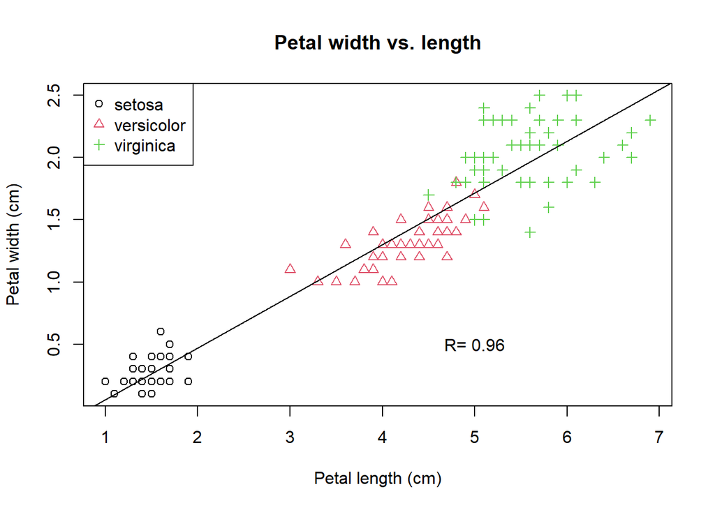

The last expression adds a legend at the top left using the *legend* function. While **plot** is a high-level graphics function that starts a new plot, **abline**, **text**, and **legend** are all low-level functions that can be added to an existing plot. You should be proud of yourself if you are able to generate this plot. This is how we create complex plots step-by-step with trial-and-error.

Such a refinement process can be time-consuming. But another open secret of coding is that we frequently steal others ideas and code. The book [R Graphics Cookbook](https://r-graphics.org/) includes all kinds of R plots and example code. Some websites list all sorts of R graphics and example codes that you can use. For example, this [website:](http://www.r-graph-gallery.com/) http://www.r-graph-gallery.com/ contains more than 200 such examples. Another one is available [here:](http://bxhorn.com/r-graphics-gallery/): http://bxhorn.com/r-graphics-gallery/. If you know what types of graphs you want, it is very easy to start with the template code and swap out the dataset.

## Scatter plot matrix

While data frames can have a mixture of numbers and characters in different columns, a **matrix often only contains numbers**. Let’s extract the first 4 columns from the data frame iris and convert to a matrix:

```r
ma <- as.matrix(iris[, 1:4]) # convert to matrix
colMeans(ma) # column means for matrix
```

```
## Sepal.Length  Sepal.Width Petal.Length  Petal.Width
##     5.843333     3.057333     3.758000     1.199333
```

```r
colSums(ma)
```

```
## Sepal.Length  Sepal.Width Petal.Length  Petal.Width
##        876.5        458.6        563.7        179.9
```

The same thing can be done with rows via *rowMeans(x)* and *rowSums(x)*.

We can generate a matrix of scatter plot by *pairs()* function.

```r
pairs(ma)
```

(ref:spm2-2) Scatter plot matrix

[figure not shown]

```
>
Interpret the scatter plot matrix of Figure \@ref(fig:spm2-2) .
```

```
>
Plot a scatter plot matrix for dataset **mtcars**. Set different point symbols and colors based on the types of *cyl*.
```

```r
pairs(ma, col = rainbow(3)[speciesID]) # set colors by species
```

## Star and segment diagrams

**Star plot uses stars to visualize multidimensional data.** Radar chart is a useful way to display multivariate observations with an arbitrary number of variables. Each observation is represented as a star-shaped figure with one ray for each variable. For a given observation, the length of each ray is made proportional to the size of that variable. The star plot was firstly used by Georg von Mayr in 1877!

```r
df <- iris[, 1:4]
stars(df) # do I see any diamonds?
stars(df, key.loc = c(17, 0)) # What does this tell you?
```

```
>
Based on the star plot, what is your overall impression regarding the differences among these 3 species of flowers?
```

The stars() function can also be used to generate segment diagrams, where each variable is used to generate colorful segments. The sizes of the segments are proportional to the measurements.

```r
stars(df, key.loc = c(20, 0.5), draw.segments = TRUE)
```

(ref:12-4) Star plots and segments diagrams.

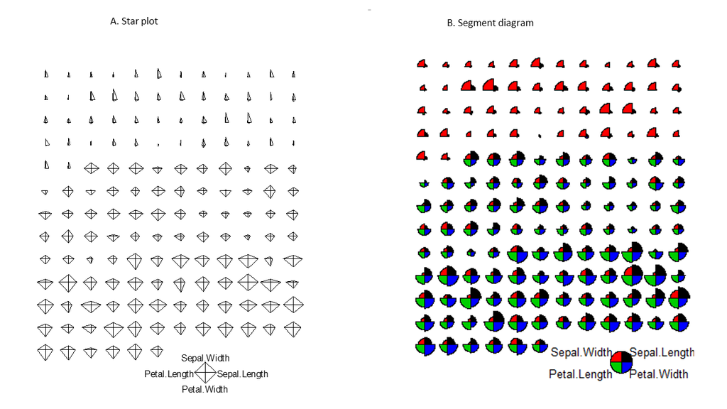

```
>
Produce the segments diagram of the state data (state.x77) and offer some interpretation of South Dakota compared with other states. Hints: Convert the matrix to a data frame using *df.state.x77 <- as.data.frame(state.x77)*, then plot the segments diagram based on the dataset *df.state.x77*.
```